# Airbnb Pricing Analysis Across European Cities

This project presents an Exploratory Data Analysis (EDA) of Airbnb listing prices across 10 major European cities.

The goal is to understand which factors influence listing prices, including location, property characteristics, and host attributes.

The dataset contains over 51,000 Airbnb listings collected across multiple cities and separated into weekday and weekend pricing.

This project follows a typical EDA workflow including data preparation, data exploration, visualization, and interpretation of insights.

The analysis focuses on exploring questions such as:

- How do Airbnb prices vary across cities?
- Do weekend listings have higher prices than weekday listings?
- How does property type influence price?
- Does distance from the city center affect pricing?
- Do superhosts charge higher prices?

The analysis is performed using Python using the following libraries:

- pandas
- matplotlib
- seaborn

The dataset used in this project is publicly available on Kaggle: https://www.kaggle.com/datasets/thedevastator/airbnb-prices-in-european-cities

## Section 1: Data Preparation

```python
# Data manipulation
import pandas as pd
import numpy as np

# Visualization
import matplotlib.pyplot as plt
import seaborn as sns

# Plot style
sns.set_style("whitegrid")

# Reveal all columns
pd.set_option("display.max_columns", None)
```

```python
# Load Airbnb datasets for each city and day type
# Add two columns:
# - city: name of the city
# - day_type: Weekday or Weekend

# Amsterdam
amsterdam_weekdays = pd.read_csv("data/amsterdam_weekdays.csv")
amsterdam_weekdays["city"] = "Amsterdam"
amsterdam_weekdays["day_type"] = "Weekday"

amsterdam_weekends = pd.read_csv("data/amsterdam_weekends.csv")
amsterdam_weekends["city"] = "Amsterdam"
amsterdam_weekends["day_type"] = "Weekend"


# Athens
athens_weekdays = pd.read_csv("data/athens_weekdays.csv")
athens_weekdays["city"] = "Athens"
athens_weekdays["day_type"] = "Weekday"

athens_weekends = pd.read_csv("data/athens_weekends.csv")
athens_weekends["city"] = "Athens"
athens_weekends["day_type"] = "Weekend"


# Barcelona
barcelona_weekdays = pd.read_csv("data/barcelona_weekdays.csv")
barcelona_weekdays["city"] = "Barcelona"
barcelona_weekdays["day_type"] = "Weekday"

barcelona_weekends = pd.read_csv("data/barcelona_weekends.csv")
barcelona_weekends["city"] = "Barcelona"
barcelona_weekends["day_type"] = "Weekend"


# Berlin
berlin_weekdays = pd.read_csv("data/berlin_weekdays.csv")
berlin_weekdays["city"] = "Berlin"
berlin_weekdays["day_type"] = "Weekday"

berlin_weekends = pd.read_csv("data/berlin_weekends.csv")
berlin_weekends["city"] = "Berlin"
berlin_weekends["day_type"] = "Weekend"


# Budapest
budapest_weekdays = pd.read_csv("data/budapest_weekdays.csv")
budapest_weekdays["city"] = "Budapest"
budapest_weekdays["day_type"] = "Weekday"

budapest_weekends = pd.read_csv("data/budapest_weekends.csv")
budapest_weekends["city"] = "Budapest"
budapest_weekends["day_type"] = "Weekend"


# Lisbon
lisbon_weekdays = pd.read_csv("data/lisbon_weekdays.csv")
lisbon_weekdays["city"] = "Lisbon"
lisbon_weekdays["day_type"] = "Weekday"

lisbon_weekends = pd.read_csv("data/lisbon_weekends.csv")
lisbon_weekends["city"] = "Lisbon"
lisbon_weekends["day_type"] = "Weekend"


# London
london_weekdays = pd.read_csv("data/london_weekdays.csv")
london_weekdays["city"] = "London"
london_weekdays["day_type"] = "Weekday"

london_weekends = pd.read_csv("data/london_weekends.csv")
london_weekends["city"] = "London"
london_weekends["day_type"] = "Weekend"


# Paris
paris_weekdays = pd.read_csv("data/paris_weekdays.csv")
paris_weekdays["city"] = "Paris"
paris_weekdays["day_type"] = "Weekday"

paris_weekends = pd.read_csv("data/paris_weekends.csv")
paris_weekends["city"] = "Paris"
paris_weekends["day_type"] = "Weekend"


# Rome
rome_weekdays = pd.read_csv("data/rome_weekdays.csv")
rome_weekdays["city"] = "Rome"
rome_weekdays["day_type"] = "Weekday"

rome_weekends = pd.read_csv("data/rome_weekends.csv")
rome_weekends["city"] = "Rome"
rome_weekends["day_type"] = "Weekend"


# Vienna
vienna_weekdays = pd.read_csv("data/vienna_weekdays.csv")
vienna_weekdays["city"] = "Vienna"
vienna_weekdays["day_type"] = "Weekday"

vienna_weekends = pd.read_csv("data/vienna_weekends.csv")
vienna_weekends["city"] = "Vienna"
vienna_weekends["day_type"] = "Weekend"
```

```python
# Combine all city datasets into one dataframe

df = pd.concat([
amsterdam_weekdays,
amsterdam_weekends,
athens_weekdays,
athens_weekends,
barcelona_weekdays,
barcelona_weekends,
berlin_weekdays,
berlin_weekends,
budapest_weekdays,
budapest_weekends,
lisbon_weekdays,
lisbon_weekends,
london_weekdays,
london_weekends,
paris_weekdays,
paris_weekends,
rome_weekdays,
rome_weekends,
vienna_weekdays,
vienna_weekends
], ignore_index=True)
```

## Section 2: Initial Data Exploration

```python
# Check dataset size
df.shape
```

```
(51707, 22)
```

```python
df.head()
```

|  | Unnamed: 0 | realSum | room_type | room_shared | room_private | person_capacity | host_is_superhost | multi | biz | cleanliness_rating | guest_satisfaction_overall | bedrooms | dist | metro_dist | attr_index | attr_index_norm | rest_index | rest_index_norm | lng | lat | city | day_type |
| --- | --- | --- | --- | --- | --- | --- | --- | --- | --- | --- | --- | --- | --- | --- | --- | --- | --- | --- | --- | --- | --- | --- |
| 0 | 0 | 194.033698 | Private room | False | True | 2.0 | False | 1 | 0 | 10.0 | 93.0 | 1 | 5.022964 | 2.539380 | 78.690379 | 4.166708 | 98.253896 | 6.846473 | 4.90569 | 52.41772 | Amsterdam | Weekday |
| 1 | 1 | 344.245776 | Private room | False | True | 4.0 | False | 0 | 0 | 8.0 | 85.0 | 1 | 0.488389 | 0.239404 | 631.176378 | 33.421209 | 837.280757 | 58.342928 | 4.90005 | 52.37432 | Amsterdam | Weekday |
| 2 | 2 | 264.101422 | Private room | False | True | 2.0 | False | 0 | 1 | 9.0 | 87.0 | 1 | 5.748312 | 3.651621 | 75.275877 | 3.985908 | 95.386955 | 6.646700 | 4.97512 | 52.36103 | Amsterdam | Weekday |
| 3 | 3 | 433.529398 | Private room | False | True | 4.0 | False | 0 | 1 | 9.0 | 90.0 | 2 | 0.384862 | 0.439876 | 493.272534 | 26.119108 | 875.033098 | 60.973565 | 4.89417 | 52.37663 | Amsterdam | Weekday |
| 4 | 4 | 485.552926 | Private room | False | True | 2.0 | True | 0 | 0 | 10.0 | 98.0 | 1 | 0.544738 | 0.318693 | 552.830324 | 29.272733 | 815.305740 | 56.811677 | 4.90051 | 52.37508 | Amsterdam | Weekday |

```python
df.info()
```

```
<class 'pandas.core.frame.DataFrame'>
RangeIndex: 51707 entries, 0 to 51706
Data columns (total 22 columns):
 #   Column                      Non-Null Count  Dtype
---  ------                      --------------  -----
 0   Unnamed: 0                  51707 non-null  int64
 1   realSum                     51707 non-null  float64
 2   room_type                   51707 non-null  object
 3   room_shared                 51707 non-null  bool
 4   room_private                51707 non-null  bool
 5   person_capacity             51707 non-null  float64
 6   host_is_superhost           51707 non-null  bool
 7   multi                       51707 non-null  int64
 8   biz                         51707 non-null  int64
 9   cleanliness_rating          51707 non-null  float64
 10  guest_satisfaction_overall  51707 non-null  float64
 11  bedrooms                    51707 non-null  int64
 12  dist                        51707 non-null  float64
 13  metro_dist                  51707 non-null  float64
 14  attr_index                  51707 non-null  float64
 15  attr_index_norm             51707 non-null  float64
 16  rest_index                  51707 non-null  float64
 17  rest_index_norm             51707 non-null  float64
 18  lng                         51707 non-null  float64
 19  lat                         51707 non-null  float64
 20  city                        51707 non-null  object
 21  day_type                    51707 non-null  object
dtypes: bool(3), float64(12), int64(4), object(3)
memory usage: 7.6+ MB
```

```python
df.describe()
```

|  | Unnamed: 0 | realSum | person_capacity | multi | biz | cleanliness_rating | guest_satisfaction_overall | bedrooms | dist | metro_dist | attr_index | attr_index_norm | rest_index | rest_index_norm | lng | lat |
| --- | --- | --- | --- | --- | --- | --- | --- | --- | --- | --- | --- | --- | --- | --- | --- | --- |
| count | 51707.000000 | 51707.000000 | 51707.000000 | 51707.000000 | 51707.000000 | 51707.000000 | 51707.000000 | 51707.00000 | 51707.000000 | 51707.000000 | 51707.000000 | 51707.000000 | 51707.000000 | 51707.000000 | 51707.000000 | 51707.000000 |
| mean | 1620.502388 | 279.879591 | 3.161661 | 0.291353 | 0.350204 | 9.390624 | 92.628232 | 1.15876 | 3.191285 | 0.681540 | 294.204105 | 13.423792 | 626.856696 | 22.786177 | 7.426068 | 45.671128 |
| std | 1217.380366 | 327.948386 | 1.298545 | 0.454390 | 0.477038 | 0.954868 | 8.945531 | 0.62741 | 2.393803 | 0.858023 | 224.754123 | 9.807985 | 497.920226 | 17.804096 | 9.799725 | 5.249263 |
| min | 0.000000 | 34.779339 | 2.000000 | 0.000000 | 0.000000 | 2.000000 | 20.000000 | 0.00000 | 0.015045 | 0.002301 | 15.152201 | 0.926301 | 19.576924 | 0.592757 | -9.226340 | 37.953000 |
| 25% | 646.000000 | 148.752174 | 2.000000 | 0.000000 | 0.000000 | 9.000000 | 90.000000 | 1.00000 | 1.453142 | 0.248480 | 136.797385 | 6.380926 | 250.854114 | 8.751480 | -0.072500 | 41.399510 |
| 50% | 1334.000000 | 211.343089 | 3.000000 | 0.000000 | 0.000000 | 10.000000 | 95.000000 | 1.00000 | 2.613538 | 0.413269 | 234.331748 | 11.468305 | 522.052783 | 17.542238 | 4.873000 | 47.506690 |
| 75% | 2382.000000 | 319.694287 | 4.000000 | 1.000000 | 1.000000 | 10.000000 | 99.000000 | 1.00000 | 4.263077 | 0.737840 | 385.756381 | 17.415082 | 832.628988 | 32.964603 | 13.518825 | 51.471885 |
| max | 5378.000000 | 18545.450285 | 6.000000 | 1.000000 | 1.000000 | 10.000000 | 100.000000 | 10.00000 | 25.284557 | 14.273577 | 4513.563486 | 100.000000 | 6696.156772 | 100.000000 | 23.786020 | 52.641410 |

## Section 3: Data Cleaning

```python
# Remove unnecessary index column from original dataset
df = df.drop(columns=["Unnamed: 0"])
```

```python
# Rename price column for clarity
df = df.rename(columns={"realSum": "price"})
```

```python
# Check for duplicate rows
df.duplicated().sum()
```

```
np.int64(0)
```

```python
# Check for null values
df.isnull().sum()
```

```
price                         0
room_type                     0
room_shared                   0
room_private                  0
person_capacity               0
host_is_superhost             0
multi                         0
biz                           0
cleanliness_rating            0
guest_satisfaction_overall    0
bedrooms                      0
dist                          0
metro_dist                    0
attr_index                    0
attr_index_norm               0
rest_index                    0
rest_index_norm               0
lng                           0
lat                           0
city                          0
day_type                      0
dtype: int64
```

```python
# Preview cleaned dataset
df.head()
```

|  | price | room_type | room_shared | room_private | person_capacity | host_is_superhost | multi | biz | cleanliness_rating | guest_satisfaction_overall | bedrooms | dist | metro_dist | attr_index | attr_index_norm | rest_index | rest_index_norm | lng | lat | city | day_type |
| --- | --- | --- | --- | --- | --- | --- | --- | --- | --- | --- | --- | --- | --- | --- | --- | --- | --- | --- | --- | --- | --- |
| 0 | 194.033698 | Private room | False | True | 2.0 | False | 1 | 0 | 10.0 | 93.0 | 1 | 5.022964 | 2.539380 | 78.690379 | 4.166708 | 98.253896 | 6.846473 | 4.90569 | 52.41772 | Amsterdam | Weekday |
| 1 | 344.245776 | Private room | False | True | 4.0 | False | 0 | 0 | 8.0 | 85.0 | 1 | 0.488389 | 0.239404 | 631.176378 | 33.421209 | 837.280757 | 58.342928 | 4.90005 | 52.37432 | Amsterdam | Weekday |
| 2 | 264.101422 | Private room | False | True | 2.0 | False | 0 | 1 | 9.0 | 87.0 | 1 | 5.748312 | 3.651621 | 75.275877 | 3.985908 | 95.386955 | 6.646700 | 4.97512 | 52.36103 | Amsterdam | Weekday |
| 3 | 433.529398 | Private room | False | True | 4.0 | False | 0 | 1 | 9.0 | 90.0 | 2 | 0.384862 | 0.439876 | 493.272534 | 26.119108 | 875.033098 | 60.973565 | 4.89417 | 52.37663 | Amsterdam | Weekday |
| 4 | 485.552926 | Private room | False | True | 2.0 | True | 0 | 0 | 10.0 | 98.0 | 1 | 0.544738 | 0.318693 | 552.830324 | 29.272733 | 815.305740 | 56.811677 | 4.90051 | 52.37508 | Amsterdam | Weekday |

## Section 4: Exploratory Data Analysis

```python
# Distribution of listings by city
df["city"].value_counts()
```

```
city
London       9993
Rome         9027
Paris        6688
Lisbon       5763
Athens       5280
Budapest     4022
Vienna       3537
Barcelona    2833
Berlin       2484
Amsterdam    2080
Name: count, dtype: int64
```

```python
# Distribution of room types
df["room_type"].value_counts()
```

```
room_type
Entire home/apt    32648
Private room       18693
Shared room          366
Name: count, dtype: int64
```

```python
# Distribution of listings by day type
df["day_type"].value_counts()
```

```
day_type
Weekend    26207
Weekday    25500
Name: count, dtype: int64
```

```python
# Distribution of superhost status
df["host_is_superhost"].value_counts()
```

```
host_is_superhost
False    38475
True     13232
Name: count, dtype: int64
```

```python
df.describe()
```

|  | price | person_capacity | multi | biz | cleanliness_rating | guest_satisfaction_overall | bedrooms | dist | metro_dist | attr_index | attr_index_norm | rest_index | rest_index_norm | lng | lat |
| --- | --- | --- | --- | --- | --- | --- | --- | --- | --- | --- | --- | --- | --- | --- | --- |
| count | 51707.000000 | 51707.000000 | 51707.000000 | 51707.000000 | 51707.000000 | 51707.000000 | 51707.00000 | 51707.000000 | 51707.000000 | 51707.000000 | 51707.000000 | 51707.000000 | 51707.000000 | 51707.000000 | 51707.000000 |
| mean | 279.879591 | 3.161661 | 0.291353 | 0.350204 | 9.390624 | 92.628232 | 1.15876 | 3.191285 | 0.681540 | 294.204105 | 13.423792 | 626.856696 | 22.786177 | 7.426068 | 45.671128 |
| std | 327.948386 | 1.298545 | 0.454390 | 0.477038 | 0.954868 | 8.945531 | 0.62741 | 2.393803 | 0.858023 | 224.754123 | 9.807985 | 497.920226 | 17.804096 | 9.799725 | 5.249263 |
| min | 34.779339 | 2.000000 | 0.000000 | 0.000000 | 2.000000 | 20.000000 | 0.00000 | 0.015045 | 0.002301 | 15.152201 | 0.926301 | 19.576924 | 0.592757 | -9.226340 | 37.953000 |
| 25% | 148.752174 | 2.000000 | 0.000000 | 0.000000 | 9.000000 | 90.000000 | 1.00000 | 1.453142 | 0.248480 | 136.797385 | 6.380926 | 250.854114 | 8.751480 | -0.072500 | 41.399510 |
| 50% | 211.343089 | 3.000000 | 0.000000 | 0.000000 | 10.000000 | 95.000000 | 1.00000 | 2.613538 | 0.413269 | 234.331748 | 11.468305 | 522.052783 | 17.542238 | 4.873000 | 47.506690 |
| 75% | 319.694287 | 4.000000 | 1.000000 | 1.000000 | 10.000000 | 99.000000 | 1.00000 | 4.263077 | 0.737840 | 385.756381 | 17.415082 | 832.628988 | 32.964603 | 13.518825 | 51.471885 |
| max | 18545.450285 | 6.000000 | 1.000000 | 1.000000 | 10.000000 | 100.000000 | 10.00000 | 25.284557 | 14.273577 | 4513.563486 | 100.000000 | 6696.156772 | 100.000000 | 23.786020 | 52.641410 |

```python
# Set global color palette for visualizations
palette = sns.color_palette("crest")
```

#### The first step is to explore the overall distribution of Airbnb listing prices.

This initial visualization includes all listings and helps identify the general shape of the price distribution.

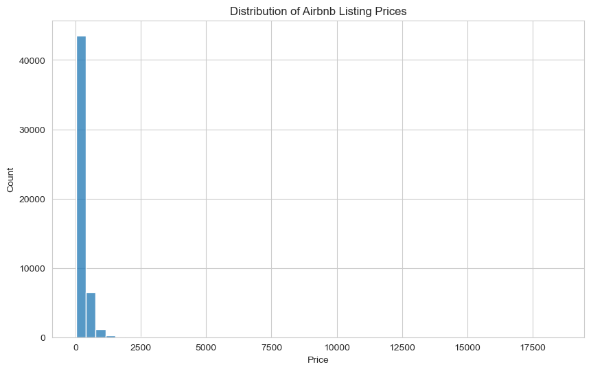

```python
plt.figure(figsize=(10,6))

sns.histplot(df["price"], bins=50)

plt.title("Distribution of Airbnb Listing Prices")
plt.xlabel("Price")
plt.ylabel("Count")

plt.savefig("images/price_distribution_including_outliers.png", bbox_inches="tight")
plt.show()
```

The distribution is heavily right-skewed, with a small number of extremely expensive listings.

These outliers make it difficult to clearly observe the main price distribution.

To improve visualization, we limit the data to the 99th percentile of prices.

```python
price_limit = df["price"].quantile(0.99)

price_limit
```

```
np.float64(1160.8363319927585)
```

```python
df_filtered = df[df["price"] <= price_limit]
```

Listings above the 99th percentile are removed only for visualization purposes to better observe the main distribution.

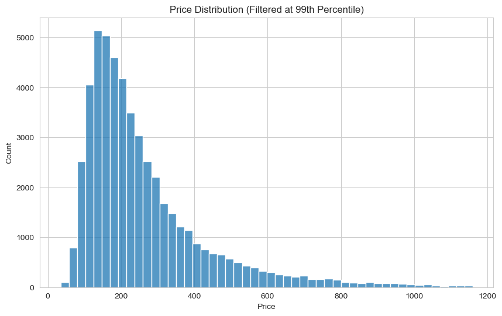

```python
plt.figure(figsize=(10,6))

sns.histplot(df_filtered["price"], bins=50)

plt.title("Price Distribution (Filtered at 99th Percentile)")
plt.xlabel("Price")
plt.ylabel("Count")

plt.savefig("images/price_distribution.png", bbox_inches="tight")
plt.show()
```

The price distribution is right-skewed, with most listings concentrated at lower price ranges and a long tail of high-priced listings.

After removing extreme outliers, the main distribution becomes clearer, showing that the majority of Airbnb listings fall within a moderate price range.

#### After understanding the overall price distribution, we compare average listing prices across cities to identify which locations are more expensive.

[figure not shown]

```python
# Calculate average price by city
city_price = df_filtered.groupby("city")["price"].mean().sort_values(ascending=False)

plt.figure(figsize=(10,6))

sns.barplot(x=city_price.values, y=city_price.index)

plt.title("Average Airbnb Price by City")
plt.xlabel("Average Price")
plt.ylabel("City")

plt.savefig("images/avg_price_by_city.png", bbox_inches="tight")
plt.show()
```

Average listing prices vary significantly across cities, with Amsterdam, Paris, and London being the most expensive.

In contrast, cities like Athens and Budapest show considerably lower average prices, highlighting strong geographical differences in Airbnb pricing across Europe.

#### Next, we analyze how listing prices vary across different room types.

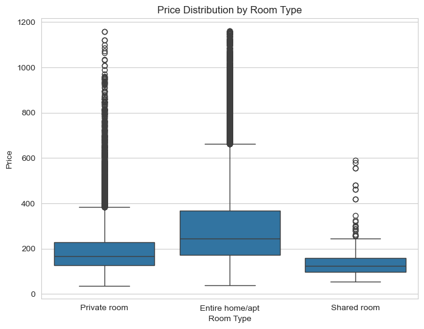

```python
plt.figure(figsize=(8,6))

sns.boxplot(data=df_filtered, x="room_type", y="price")

plt.title("Price Distribution by Room Type")
plt.xlabel("Room Type")
plt.ylabel("Price")

plt.savefig("images/price_distribution_by_room_type.png", bbox_inches="tight")
plt.show()
```

Entire homes/apartments have the highest median prices, followed by private rooms, while shared rooms are the most affordable.

The wide spread and presence of outliers indicate high variability in pricing within each room type.

#### We now examine how listing price varies with guest capacity.

This helps us understand whether larger accommodations tend to have higher prices.

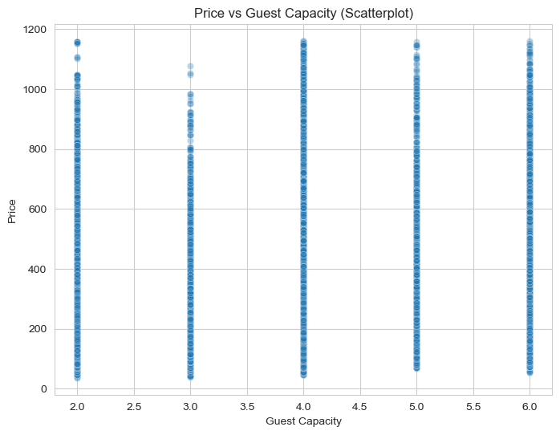

```python
plt.figure(figsize=(8,6))

sns.scatterplot(data=df_filtered, x="person_capacity", y="price", alpha=0.3)

plt.title("Price vs Guest Capacity (Scatterplot)")
plt.xlabel("Guest Capacity")
plt.ylabel("Price")

plt.savefig("images/price_vs_guest_capacity_scatterplot.png", bbox_inches="tight")
plt.show()
```

The plot shows a slight increase in price as guest capacity increases.

However, there is significant overlap in prices across different capacity levels, indicating that capacity alone is not a strong predictor of price.

This suggests that other factors, such as location and property type, play a more important role in determining listing prices.

To better understand the distribution, we also summarize the relationship using a boxplot.

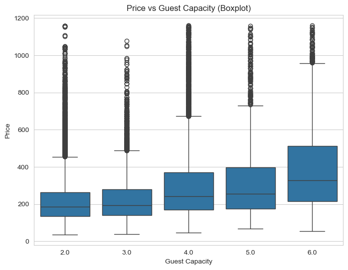

```python
plt.figure(figsize=(8,6))

sns.boxplot(
    data=df_filtered,
    x="person_capacity",
    y="price"
)

plt.title("Price vs Guest Capacity (Boxplot)")
plt.xlabel("Guest Capacity")
plt.ylabel("Price")

plt.savefig("images/price_vs_guest_capacity_boxplot.png", bbox_inches="tight")
plt.show()
```

The boxplot shows a clear increase in median price as guest capacity increases.

However, there is still considerable overlap between categories, indicating that while larger properties tend to be more expensive, capacity alone does not fully explain price differences.

#### Moving forward, we analyze how listing prices vary with distance from the city center and metro accessibility.

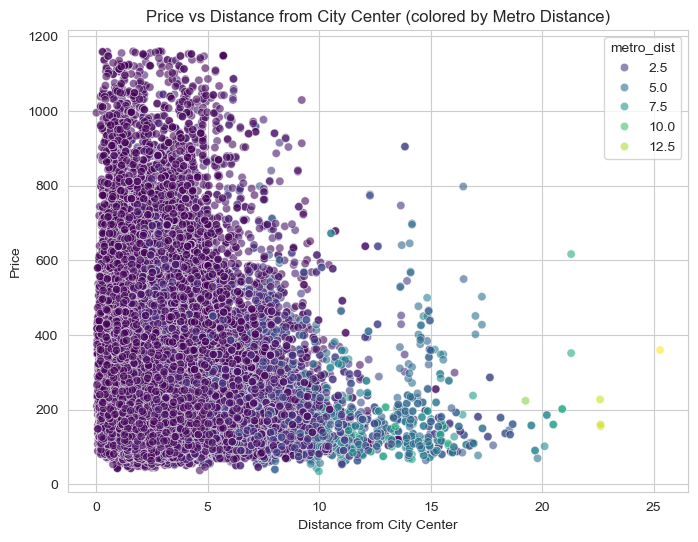

```python
plt.figure(figsize=(8,6))

sns.scatterplot(
    data=df_filtered,
    x="dist",
    y="price",
    hue="metro_dist",
    palette="viridis",
    alpha=0.6
)

plt.title("Price vs Distance from City Center (colored by Metro Distance)")
plt.xlabel("Distance from City Center")
plt.ylabel("Price")

plt.savefig("images/price_vs_city_center_dist_vs_metro_dist.png", bbox_inches="tight")
plt.show()
```

The plot shows that listings closer to both the city center and metro stations tend to have higher prices.

Properties located farther from metro access and the city center are generally associated with lower prices, suggesting that accessibility and transportation convenience play an important role in pricing.

So location is a very important factor for the price.

#### In this step, we examine whether superhost status has an impact on listing prices.

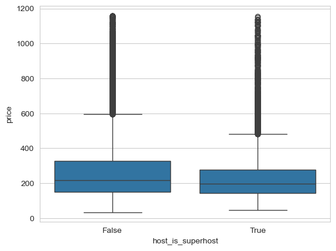

```python
sns.boxplot(data=df_filtered, x="host_is_superhost", y="price")
plt.savefig("images/host_is_superhost.png", bbox_inches="tight")
```

The boxplot shows that non-superhosts have a slightly higher median price than superhosts in this dataset.

This suggests that superhost status alone does not necessarily lead to higher listing prices, and other factors such as location, property type, or city composition may have a stronger influence.

#### Here, we explore how price distributions differ across cities after removing extreme outliers.

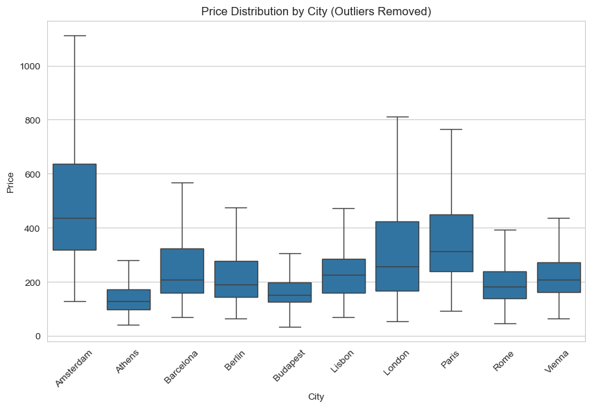

```python
plt.figure(figsize=(10,6))

sns.boxplot(data=df_filtered, x="city", y="price", showfliers=False)

plt.title("Price Distribution by City (Outliers Removed)")
plt.xlabel("City")
plt.ylabel("Price")

plt.xticks(rotation=45)

plt.savefig("images/price_distribution_by_city.png", bbox_inches="tight")
plt.show()
```

The distribution of prices varies significantly across cities, with some cities showing higher median prices and wider spreads.

Cities such as Amsterdam, Paris, and London tend to have higher typical prices, while others like Athens and Budapest remain more affordable, confirming strong regional differences in pricing.

This boxplot is displayed without outliers to better highlight the central distribution.

#### Additionally, we compare average listing prices between weekdays and weekends across different cities.

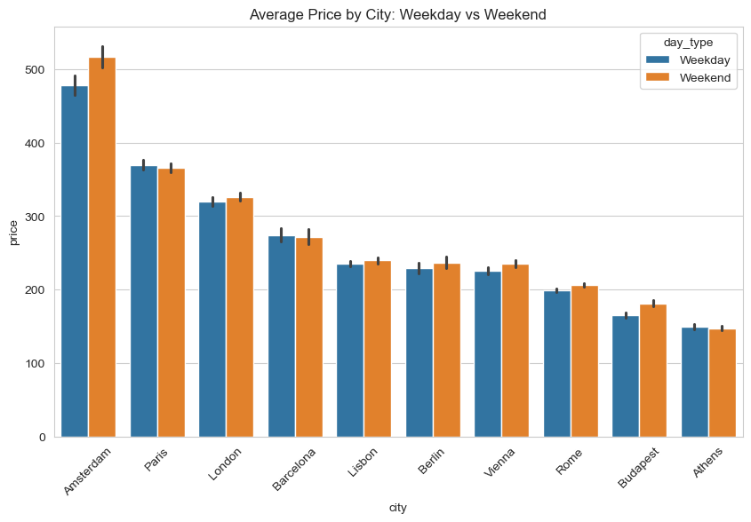

```python
plt.figure(figsize=(10,6))

city_order = (
    df_filtered[df_filtered["day_type"] == "Weekend"]
    .groupby("city")["price"]
    .mean()
    .sort_values(ascending = False)
    .index
)

sns.barplot(
    data=df_filtered,
    x="city",
    y="price",
    hue="day_type",
    order=city_order
)

plt.title("Average Price by City: Weekday vs Weekend")
plt.xticks(rotation=45)

plt.savefig("images/avg_price_by_city_weekday_vs_weekend.png", bbox_inches="tight")
plt.show()
```

The chart shows clear differences in average Airbnb prices across cities, with Amsterdam, Paris, and London being the most expensive, while Budapest and Athens are among the most affordable.

In most cities, weekend prices are slightly higher than weekday prices, indicating increased demand during weekends. However, the overall price differences between cities are more significant than the weekday-weekend variation.

#### Finally, we analyze the relationships between numerical features to understand how different variables are associated with price.

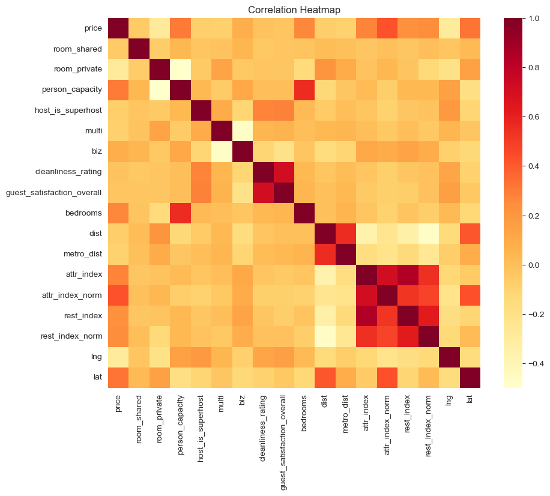

```python
plt.figure(figsize=(10,8))

sns.heatmap(df_filtered.corr(numeric_only=True), annot=False, cmap="YlOrRd")

plt.title("Correlation Heatmap")

plt.savefig("images/correlation_map.png", bbox_inches="tight")
plt.show()
```

The correlation heatmap shows that price has moderate relationships with variables such as guest capacity, number of bedrooms, and location-related features.

Distance from the city center is negatively correlated with price, confirming that properties farther away tend to be cheaper. Additionally, strong correlations are observed among location-based indices (attraction and restaurant indexes), indicating they capture similar aspects of location quality.

Overall, no single variable strongly determines price, suggesting that Airbnb pricing is influenced by a combination of multiple factors.

## Section 5: Key Insights & Conclusions

This exploratory analysis identified several key factors influencing Airbnb listing prices across European cities.

- **Location is the most important driver of price**: Listings closer to the city center and metro stations tend to have higher prices, while prices decrease as distance increases.
- **Significant differences exist across cities**: Cities such as Amsterdam, Paris, and London have considerably higher average prices compared to cities like Athens and Budapest.
- **Property size influences pricing, but not strongly alone**: Listings with higher guest capacity and more bedrooms tend to be more expensive, but there is substantial overlap, indicating other factors also play a role.
- **Room type has a clear impact**: Entire homes/apartments are generally the most expensive, while shared rooms are the most affordable.
- **Weekend pricing is slightly higher**: Prices tend to increase during weekends, although this effect is smaller compared to location and city differences.
- **No single variable fully explains price**: The correlation analysis shows that pricing is influenced by a combination of factors rather than one dominant variable.

Overall, Airbnb pricing is a multi-factor problem where location, property characteristics, and city-specific dynamics interact to determine listing prices.

These insights can be valuable for hosts when setting competitive prices, as well as for travelers seeking better value based on location and timing.

While the dataset clearly shows that cities like London, Paris, and Amsterdam have higher Airbnb prices compared to cities such as Athens and Budapest, the underlying reasons are not directly captured in the data. These differences are likely influenced by external factors such as cost of living, tourism demand, local income levels, and broader market conditions, which are beyond the scope of this dataset.

Therefore, although strong pricing patterns are identified, additional data would be required to fully explain the causes behind these differences.